# running_test

```python
from google.colab import drive
drive.mount('/content/drive')
import os
os.chdir("/content/drive/My Drive/capstone_project")
```

[output not shown]

import所需要的调用包

```python
from crnn_model import train
import pandas as pd
import numpy as np
from dataset_util import *
from util import *
import os
import matplotlib.pylab as plt
%matplotlib inline
%reload_ext autoreload
%autoreload 2
```

```python
num_class = 10 + 6 + 2
map_class={}
keys = '0123456789+-*=()'
for i in range(len('0123456789+-*=()')):
    map_class[keys[i]]=i
print(map_class)
```

```
{'0': 0, '1': 1, '2': 2, '3': 3, '4': 4, '5': 5, '6': 6, '7': 7, '8': 8, '9': 9, '+': 10, '-': 11, '*': 12, '=': 13, '(': 14, ')': 15}
```

把10万张图片和算式标签转换成tfrecord文件，方便数据的调用

```python
make_tfrecord()
```

```
(100000, 32, 150, 3)
Reading labels
half done!
Writing data/train.tfrecord
Writing data/validation.tfrecord
Writing data/test.tfrecord
Writing data/dataset.tfrecord
```

通过验证tfrecord文件中随机一张图片和对应标签是否一致来确定tfrecord文件中的图片集和标签集之间正确的对应关系

```
WARNING:tensorflow:From /usr/local/lib/python3.6/dist-packages/tensorflow/python/data/ops/dataset_ops.py:1419: colocate_with (from tensorflow.python.framework.ops) is deprecated and will be removed in a future version.
Instructions for updating:
Colocations handled automatically by placer.
100
```

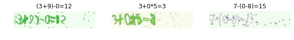

```python
tf.reset_default_graph()
dataset = batch_data( 'validation', num_epoch=1, batchsize=100)
iterator = dataset.make_initializable_iterator()
next_element = iterator.get_next()
sess = tf.Session()
sess.run(iterator.initializer)
image, label = sess.run(next_element)
label = [l.decode() for l in label]
print(len(label))
#label = transferlabeltoInt(label)
#label = decode_sparse_tensor(label)
plt.rcParams['figure.figsize'] = (10.0, 8.0)
plt.rcParams['image.interpolation'] = 'nearest'
plt.rcParams['image.cmap'] = 'gray'
plt.subplot(1, 3, 1)
plt.imshow(image[50].astype('uint8'))
plt.axis('off')
plt.title(label[50])
plt.subplot(1, 3, 2)
plt.imshow(image[51].astype('uint8'))
plt.axis('off')
plt.title(label[51])
plt.subplot(1, 3, 3)
plt.imshow(image[52].astype('uint8'))
plt.axis('off')
plt.title(label[52])
```

对训练集，验证集，测试集中的字符数量进行统计

```python
from collections import defaultdict

def char_num_dict(datatype, batchsize=1000):
  map_char_num=defaultdict(int)
  tf.reset_default_graph()
  dataset = batch_data( datatype, batchsize=batchsize,num_epoch=1 )
  iterator = dataset.make_initializable_iterator()
  next_element = iterator.get_next()
  sess = tf.Session()
  sess.run(iterator.initializer)
  while True:
    try:
      image, label = sess.run(next_element)
      label = [l.decode() for l in label]
      for stri in label:
        for c in stri:
          map_char_num[c] +=1
    except tf.errors.OutOfRangeError:
      break
  return map_char_num

keys = '0123456789+-*=()'
train_char_num = char_num_dict('training')
sorted_train_dict = {x:train_char_num[x] for x in keys}
valid_char_num = char_num_dict('validation')
sorted_valid_dict = {x:valid_char_num[x] for x in keys}
test_char_num = char_num_dict('test')
sorted_test_dict = {x:test_char_num[x] for x in keys}
print(sorted_valid_dict)
```

```
{'0': 4742, '1': 6252, '2': 5172, '3': 4425, '4': 4520, '5': 4265, '6': 4305, '7': 3889, '8': 3973, '9': 3676, '+': 6621, '-': 8881, '*': 6754, '=': 10000, '(': 6686, ')': 6686}
```

把三种数据集的字符数量统计结果同时画在一张柱状图中以便于比较。

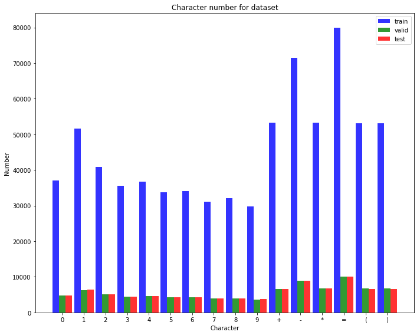

```python
import matplotlib.pylab as plt
plt.rcParams['figure.figsize'] = (10.0, 8.0)
plt.rcParams['image.interpolation'] = 'nearest'
plt.rcParams['image.cmap'] = 'gray'
# data to plot
n_groups = 16
means_train = [sorted_train_dict[k] for k in keys]
means_valid = [sorted_valid_dict[k] for k in keys]
means_test = [sorted_test_dict[k] for k in keys]

# create plot
fig, ax = plt.subplots()
index = np.arange(n_groups)
bar_width = 0.3
opacity = 0.8

rects1 = plt.bar(index, means_train, bar_width,
alpha=opacity,
color='b',
label='train')

rects2 = plt.bar(index + bar_width, means_valid, bar_width,
alpha=opacity,
color='g',
label='valid')

rects3 = plt.bar(index + 2 * bar_width, means_test, bar_width,
alpha=opacity,
color='r',
label='test')

plt.xlabel('Character')
plt.ylabel('Number')
plt.title('Character number for dataset')
plt.xticks(index + bar_width, ('0', '1', '2', '3', '4', '5', '6', '7', '8', '9', '+', '-', '*', '=', '(', ')'))
plt.legend()

plt.tight_layout()
plt.savefig('test_result/character_count.png')
plt.show()
```

index=0:表示从零开始训练模型。

index=1:表示接着saved_model中的模型继续训练。

index=2:表示只评估saved_model中的模型性能而不做任何训练。

```python
train(index=1, num_class=num_class, num_epochs=100)
```

```
71200
INFO:tensorflow:Restoring parameters from saved_model/crnn_model-89
Model in validation dataset got 9899 / 10000 correct (98.99%)
Starting epoch 90
Iteration 72000, loss = 0.0015, accuary = 0.0000
Model in validation dataset got 9880 / 10000 correct (98.80%)
Model in training dataset got 79971 / 80000 correct (99.96%)

Starting epoch 91
Iteration 72800, loss = 0.0092, accuary = 0.0000
Model in validation dataset got 9895 / 10000 correct (98.95%)

Starting epoch 92
Iteration 73600, loss = 0.0057, accuary = 0.0000
Model in validation dataset got 9896 / 10000 correct (98.96%)

Starting epoch 93
Iteration 74400, loss = 0.1310, accuary = 0.0011
Model in validation dataset got 9860 / 10000 correct (98.60%)

Starting epoch 94
Iteration 75200, loss = 0.0017, accuary = 0.0000
Model in validation dataset got 9892 / 10000 correct (98.92%)

Starting epoch 95
Iteration 76000, loss = 0.0279, accuary = 0.0010
Model in validation dataset got 9900 / 10000 correct (99.00%)

Starting epoch 96
Iteration 76800, loss = 0.0069, accuary = 0.0000
Model in validation dataset got 9895 / 10000 correct (98.95%)

Starting epoch 97
Iteration 77600, loss = 0.0118, accuary = 0.0011
Model in validation dataset got 9888 / 10000 correct (98.88%)

Starting epoch 98
Iteration 78400, loss = 0.0020, accuary = 0.0000
Model in validation dataset got 9896 / 10000 correct (98.96%)

```

[output cut: 63 more lines]

```
Iteration 90400, loss = 0.0091, accuary = 0.0011
Model in validation dataset got 9904 / 10000 correct (99.04%)
Model in test dataset got 9888 / 10000 correct (98.88%)

Starting epoch 114
Iteration 91200, loss = 0.0020, accuary = 0.0000
Model in validation dataset got 9914 / 10000 correct (99.14%)
Model in test dataset got 9891 / 10000 correct (98.91%)

Starting epoch 115
Iteration 92000, loss = 0.0227, accuary = 0.0010
Model in validation dataset got 9912 / 10000 correct (99.12%)
Model in test dataset got 9904 / 10000 correct (99.04%)
model train is successful
Model in training dataset got 79995 / 80000 correct (99.99%)
```

```
1
```

```python
train(index=2, num_class=num_class, num_epochs=100)
```

```
92000
INFO:tensorflow:Restoring parameters from saved_model/crnn_model-115
Model in training dataset got 79996 / 80000 correct (100.00%)
Model in validation dataset got 9911 / 10000 correct (99.11%)
Model in test dataset got 9900 / 10000 correct (99.00%)
```

```
0
```

从result.csv中提取训练过程产生的loss和accuracy数据

```python
training_accuracy, validation_accuracy, loss = merge_record_data()
```

画损失函数变化图

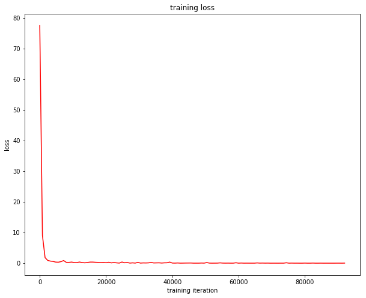

```python
plt.rcParams['figure.figsize'] = (10.0, 8.0)
plt.rcParams['image.interpolation'] = 'nearest'
plt.rcParams['image.cmap'] = 'gray'
plt.figure()
plt.title("training loss")
plt.plot(loss.keys(), list(loss.values()),color='r')
#plt.legend()
plt.xlabel("training iteration")
plt.ylabel("loss")
plt.savefig('test_result/loss.png')
plt.show()
```

画识别准确率变化图

注意：由于每隔1个epoch次数，保存一次验证集的准确率；而由于训练集具有80000个样本，所以为了降低训练时间，采取了每隔10个epoch次数才保存一次训练集的准确率的措施。因此，图像的0到8000迭代次数之间的曲线，无法反映训练集准确率的变化情况，这里是采用了线性插值的方法来填补0到8000迭代次数之间的准确率值。而超过8000迭代次数以后，训练集的准确率趋于饱和，则可以反映出训练集准确率的变化情况。

```
odict_keys([0.0, 8000.0, 16000.0, 24000.0, 32000.0, 40000.0, 48000.0, 56000.0, 64000.0, 72000.0, 80000.0, 88000.0, 92000.0]) odict_values([0.0, 97.27125, 98.63125, 99.0675, 99.5875, 99.7925, 99.8625, 99.93125, 99.9375, 99.96375, 99.97625, 99.98, 99.99375])
```

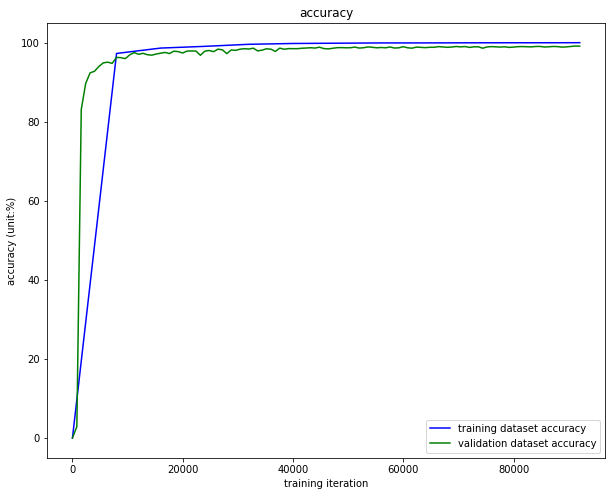

```python
print(training_accuracy.keys(),training_accuracy.values() )
plt.rcParams['figure.figsize'] = (10.0, 8.0)
plt.rcParams['image.interpolation'] = 'nearest'
plt.rcParams['image.cmap'] = 'gray'
plt.figure()
plt.title("accuracy")
plt.plot(training_accuracy.keys(), list(training_accuracy.values()),color='b',label='training dataset accuracy')
plt.plot(validation_accuracy.keys(), list(validation_accuracy.values()),color='g',label='validation dataset accuracy')
plt.legend()
plt.xlabel("training iteration")
plt.ylabel("accuracy (unit:%)")
plt.savefig('test_result/accuracy.png')
plt.show()
```